# Risk Factor Analysis

## Outcome Variable

**Outcome Variable:** s03rec24

## Predictor Variables

**Intervention Variable:** mage

**Adjustment Set:**

unadjusted

## Stratifying Variables

The analysis was stratified on these variable(s):

- studyid
- country

## Data Summary

| studyid | country | A | n | nA | nAY0 | nAY1 |
| --- | --- | --- | --- | --- | --- | --- |
| ki0047075b-MAL-ED | BANGLADESH | <20 | 247 | 32 | 31 | 1 |
| ki0047075b-MAL-ED | BANGLADESH | [20-25) | 247 | 83 | 80 | 3 |
| ki0047075b-MAL-ED | BANGLADESH | [25-30) | 247 | 90 | 86 | 4 |
| ki0047075b-MAL-ED | BANGLADESH | >=30 | 247 | 42 | 42 | 0 |
| ki0047075b-MAL-ED | BRAZIL | <20 | 223 | 43 | 38 | 5 |
| ki0047075b-MAL-ED | BRAZIL | [20-25) | 223 | 69 | 64 | 5 |
| ki0047075b-MAL-ED | BRAZIL | [25-30) | 223 | 61 | 56 | 5 |
| ki0047075b-MAL-ED | BRAZIL | >=30 | 223 | 50 | 47 | 3 |
| ki0047075b-MAL-ED | INDIA | <20 | 244 | 34 | 29 | 5 |
| ki0047075b-MAL-ED | INDIA | [20-25) | 244 | 106 | 101 | 5 |
| ki0047075b-MAL-ED | INDIA | [25-30) | 244 | 83 | 82 | 1 |
| ki0047075b-MAL-ED | INDIA | >=30 | 244 | 21 | 20 | 1 |
| ki0047075b-MAL-ED | NEPAL | <20 | 238 | 4 | 3 | 1 |
| ki0047075b-MAL-ED | NEPAL | [20-25) | 238 | 60 | 57 | 3 |
| ki0047075b-MAL-ED | NEPAL | [25-30) | 238 | 128 | 122 | 6 |
| ki0047075b-MAL-ED | NEPAL | >=30 | 238 | 46 | 45 | 1 |
| ki0047075b-MAL-ED | PERU | <20 | 284 | 78 | 72 | 6 |
| ki0047075b-MAL-ED | PERU | [20-25) | 284 | 81 | 78 | 3 |
| ki0047075b-MAL-ED | PERU | [25-30) | 284 | 61 | 54 | 7 |
| ki0047075b-MAL-ED | PERU | >=30 | 284 | 64 | 61 | 3 |
| ki0047075b-MAL-ED | SOUTH AFRICA | <20 | 302 | 47 | 45 | 2 |
| ki0047075b-MAL-ED | SOUTH AFRICA | [20-25) | 302 | 96 | 89 | 7 |
| ki0047075b-MAL-ED | SOUTH AFRICA | [25-30) | 302 | 55 | 51 | 4 |
| ki0047075b-MAL-ED | SOUTH AFRICA | >=30 | 302 | 104 | 98 | 6 |
| ki0047075b-MAL-ED | TANZANIA, UNITED REPUBLIC OF | <20 | 253 | 16 | 16 | 0 |
| ki0047075b-MAL-ED | TANZANIA, UNITED REPUBLIC OF | [20-25) | 253 | 65 | 65 | 0 |
| ki0047075b-MAL-ED | TANZANIA, UNITED REPUBLIC OF | [25-30) | 253 | 68 | 68 | 0 |
| ki0047075b-MAL-ED | TANZANIA, UNITED REPUBLIC OF | >=30 | 253 | 104 | 103 | 1 |
| ki1000108-CMC-V-BCS-2002 | INDIA | <20 | 370 | 34 | 29 | 5 |
| ki1000108-CMC-V-BCS-2002 | INDIA | [20-25) | 370 | 186 | 177 | 9 |
| ki1000108-CMC-V-BCS-2002 | INDIA | [25-30) | 370 | 107 | 104 | 3 |
| ki1000108-CMC-V-BCS-2002 | INDIA | >=30 | 370 | 43 | 43 | 0 |
| ki1000108-IRC | INDIA | <20 | 410 | 37 | 34 | 3 |
| ki1000108-IRC | INDIA | [20-25) | 410 | 221 | 206 | 15 |
| ki1000108-IRC | INDIA | [25-30) | 410 | 123 | 115 | 8 |
| ki1000108-IRC | INDIA | >=30 | 410 | 29 | 27 | 2 |
| ki1000109-EE | PAKISTAN | <20 | 174 | 0 | 0 | 0 |
| ki1000109-EE | PAKISTAN | [20-25) | 174 | 10 | 10 | 0 |
| ki1000109-EE | PAKISTAN | [25-30) | 174 | 59 | 59 | 0 |
| ki1000109-EE | PAKISTAN | >=30 | 174 | 105 | 105 | 0 |
| ki1017093b-PROVIDE | BANGLADESH | <20 | 690 | 84 | 82 | 2 |
| ki1017093b-PROVIDE | BANGLADESH | [20-25) | 690 | 279 | 272 | 7 |
| ki1017093b-PROVIDE | BANGLADESH | [25-30) | 690 | 207 | 200 | 7 |
| ki1017093b-PROVIDE | BANGLADESH | >=30 | 690 | 120 | 114 | 6 |
| ki1066203-TanzaniaChild2 | TANZANIA, UNITED REPUBLIC OF | <20 | 2258 | 154 | 154 | 0 |
| ki1066203-TanzaniaChild2 | TANZANIA, UNITED REPUBLIC OF | [20-25) | 2258 | 719 | 718 | 1 |
| ki1066203-TanzaniaChild2 | TANZANIA, UNITED REPUBLIC OF | [25-30) | 2258 | 772 | 771 | 1 |
| ki1066203-TanzaniaChild2 | TANZANIA, UNITED REPUBLIC OF | >=30 | 2258 | 613 | 613 | 0 |
| ki1101329-Keneba | GAMBIA | <20 | 2448 | 348 | 326 | 22 |
| ki1101329-Keneba | GAMBIA | [20-25) | 2448 | 629 | 601 | 28 |
| ki1101329-Keneba | GAMBIA | [25-30) | 2448 | 548 | 539 | 9 |
| ki1101329-Keneba | GAMBIA | >=30 | 2448 | 923 | 903 | 20 |
| ki1113344-GMS-Nepal | NEPAL | <20 | 594 | 121 | 115 | 6 |
| ki1113344-GMS-Nepal | NEPAL | [20-25) | 594 | 207 | 202 | 5 |
| ki1113344-GMS-Nepal | NEPAL | [25-30) | 594 | 177 | 174 | 3 |
| ki1113344-GMS-Nepal | NEPAL | >=30 | 594 | 89 | 88 | 1 |

The following strata were considered:

- studyid: ki0047075b-MAL-ED, country: BANGLADESH
- studyid: ki0047075b-MAL-ED, country: BRAZIL
- studyid: ki0047075b-MAL-ED, country: INDIA
- studyid: ki0047075b-MAL-ED, country: NEPAL
- studyid: ki0047075b-MAL-ED, country: PERU
- studyid: ki0047075b-MAL-ED, country: SOUTH AFRICA
- studyid: ki0047075b-MAL-ED, country: TANZANIA, UNITED REPUBLIC OF
- studyid: ki1000108-CMC-V-BCS-2002, country: INDIA
- studyid: ki1000108-IRC, country: INDIA
- studyid: ki1000109-EE, country: PAKISTAN
- studyid: ki1017093b-PROVIDE, country: BANGLADESH
- studyid: ki1066203-TanzaniaChild2, country: TANZANIA, UNITED REPUBLIC OF
- studyid: ki1101329-Keneba, country: GAMBIA
- studyid: ki1113344-GMS-Nepal, country: NEPAL

### Dropped Strata

Some strata were dropped due to rare outcomes:

- studyid: ki0047075b-MAL-ED, country: BANGLADESH
- studyid: ki0047075b-MAL-ED, country: BRAZIL
- studyid: ki0047075b-MAL-ED, country: INDIA
- studyid: ki0047075b-MAL-ED, country: NEPAL
- studyid: ki0047075b-MAL-ED, country: PERU
- studyid: ki0047075b-MAL-ED, country: SOUTH AFRICA
- studyid: ki0047075b-MAL-ED, country: TANZANIA, UNITED REPUBLIC OF
- studyid: ki1000108-CMC-V-BCS-2002, country: INDIA
- studyid: ki1000108-IRC, country: INDIA
- studyid: ki1000109-EE, country: PAKISTAN
- studyid: ki1017093b-PROVIDE, country: BANGLADESH
- studyid: ki1066203-TanzaniaChild2, country: TANZANIA, UNITED REPUBLIC OF
- studyid: ki1113344-GMS-Nepal, country: NEPAL

## Methods Detail

We’re interested in the causal parameters $E[Y_a]$ for all values of $a \in \mathcal{A}$. These parameters represent the mean outcome if, possibly contrary to fact, we intervened to set all units to have $A=a$. Under the randomization and positivity assumptions, these are identified by the statistical parameters $\psi_a=E_W[E_{Y|A,W}(Y|A=a,W)]$. In addition, we’re interested in the mean of $Y$, $E[Y]$ under no intervention (the observed mean). We will estimate these parameters by using SuperLearner to fit the relevant likelihood factors – $E_{Y|A,W}(Y|A=a,W)$ and $p(A=a|W)$, and then updating our likelihood fit using a joint TMLE.

For unadjusted analyses ($W=\{\}$), initial likelihoods were estimated using Lrnr_glm to estimate the simple $E(Y|A)$ and Lrnr_mean to estimate $p(A)$. For adjusted analyses, a small library containing Lrnr_glmnet, Lrnr_xgboost, and Lrnr_mean was used.

Having estimated these parameters, we will then use the delta method to estimate relative risks and attributable risks relative to a prespecified baseline level of $A$.

# Results Detail

## Results Plots

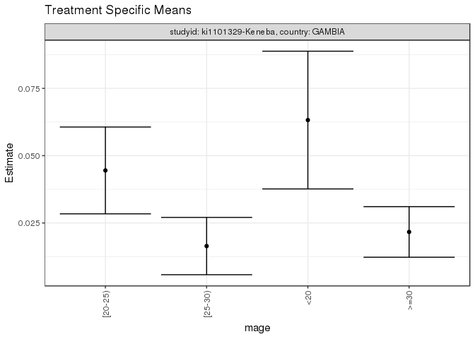

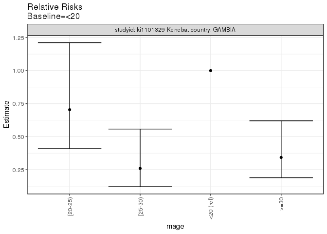

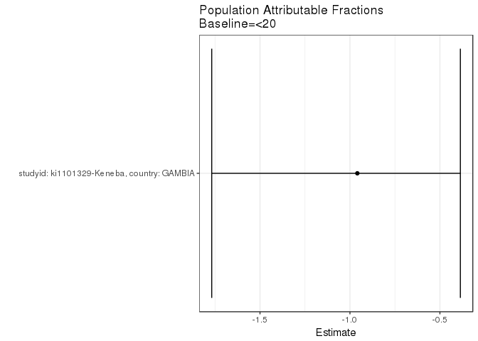

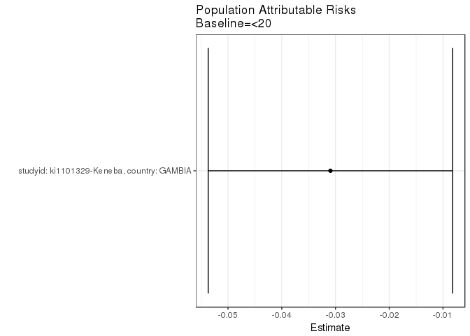

## Results Table

### Parameter: TSM

| studyid | country | intervention_level | baseline_level | estimate | ci_lower | ci_upper |
| --- | --- | --- | --- | --- | --- | --- |
| ki1101329-Keneba | GAMBIA | <20 | NA | 0.0632184 | 0.0376450 | 0.0887918 |
| ki1101329-Keneba | GAMBIA | [20-25) | NA | 0.0445151 | 0.0283947 | 0.0606356 |
| ki1101329-Keneba | GAMBIA | [25-30) | NA | 0.0164234 | 0.0057799 | 0.0270668 |
| ki1101329-Keneba | GAMBIA | >=30 | NA | 0.0216685 | 0.0122736 | 0.0310634 |

### Parameter: E(Y)

| studyid | country | intervention_level | baseline_level | estimate | ci_lower | ci_upper |
| --- | --- | --- | --- | --- | --- | --- |
| ki1101329-Keneba | GAMBIA | NA | NA | 0.0322712 | 0.0252693 | 0.0392731 |

### Parameter: RR

| studyid | country | intervention_level | baseline_level | estimate | ci_lower | ci_upper |
| --- | --- | --- | --- | --- | --- | --- |
| ki1101329-Keneba | GAMBIA | <20 | <20 | 1.0000000 | 1.0000000 | 1.0000000 |
| ki1101329-Keneba | GAMBIA | [20-25) | <20 | 0.7041480 | 0.4091374 | 1.2118776 |
| ki1101329-Keneba | GAMBIA | [25-30) | <20 | 0.2597877 | 0.1210142 | 0.5577003 |
| ki1101329-Keneba | GAMBIA | >=30 | <20 | 0.3427558 | 0.1894332 | 0.6201742 |

### Parameter: PAR

| studyid | country | intervention_level | baseline_level | estimate | ci_lower | ci_upper |
| --- | --- | --- | --- | --- | --- | --- |
| ki1101329-Keneba | GAMBIA | <20 | NA | -0.0309471 | -0.0536866 | -0.0082077 |

### Parameter: PAF

| studyid | country | intervention_level | baseline_level | estimate | ci_lower | ci_upper |
| --- | --- | --- | --- | --- | --- | --- |
| ki1101329-Keneba | GAMBIA | <20 | NA | -0.9589699 | -1.768248 | -0.3862786 |